# Data visualization with ggplot2

# **`ggplot2`** Themes

Usually plots with white background look more readable when printed. Every single component of a `ggplot()` graph can be customized using the generic `theme()` function, as we will see below. However, there are pre-loaded themes available that change the overall appearance of the graph without much effort.

For example, we can change our previous graph to have a simpler white background using the `theme_bw()` function:

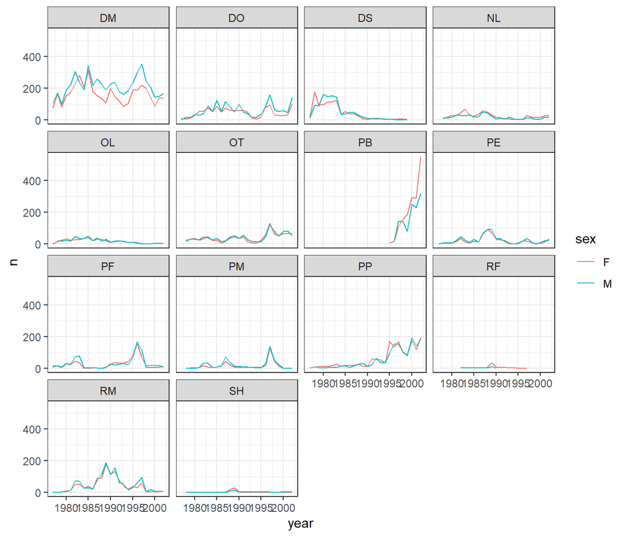

```r
yearly_sex_counts %>%
 ggplot(mapping = aes(x = year, y = n, color = sex)) +
     geom_line() +
     facet_wrap(vars(species_id)) +
     theme_bw()
```

In addition to `theme_bw()`, which changes the plot background to white, **`ggplot2`**comes with several other themes which can be useful to quickly change the look of your visualization. The complete list of themes is available at https://ggplot2.tidyverse.org/reference/ggtheme.html. `theme_minimal()` and `theme_light()` are popular, and `theme_void()` can be useful as a starting point to create a new hand-crafted theme.

The [ggthemes](https://jrnold.github.io/ggthemes/reference/index.html) package provides a wide variety of options. The [**`ggplot2`** extensions website](https://www.ggplot2-exts.org) provides a list of packages that extend the capabilities of **`ggplot2`**, including additional themes.

### Challenge 8

> Use what you just learned to add the plotting background theme of your choosing to the plot you made in Challenge 7!

```r
## Your ggplot() code for the plot goes here!
```

# Customization

Take a look at the [**`ggplot2`** cheat sheet](https://github.com/rstudio/cheatsheets/raw/master/data-visualization-2.1.pdf), and think of ways you could improve the plot.

## Plot Labels

Now, let’s change names of axes to something more informative than ‘year’ and ‘n’ and add a title to the figure. Label customizations are done using the `labs()` function like so:

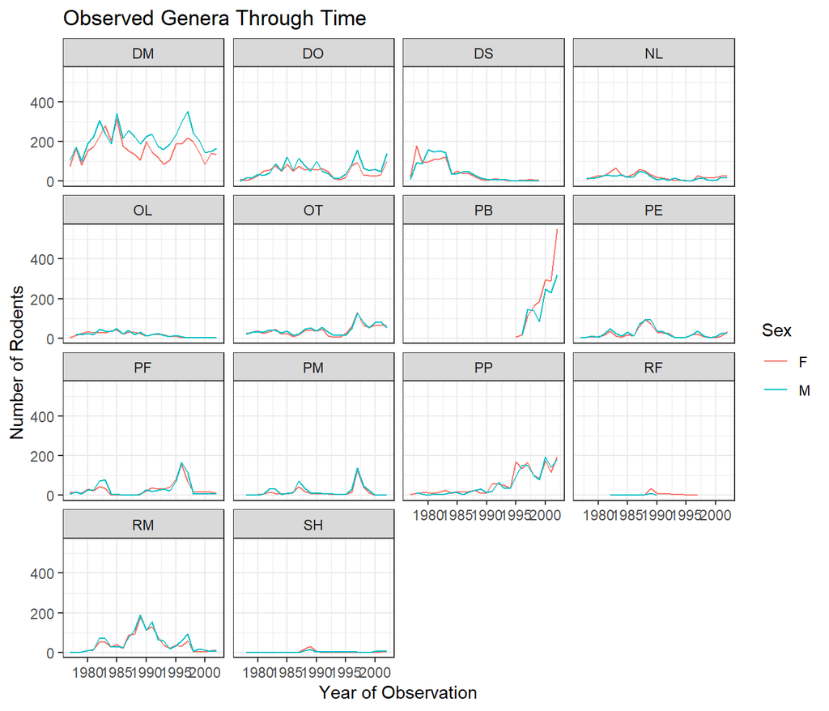

```r
yearly_sex_counts %>%
  ggplot(mapping = aes(x = year, y = n, color = sex)) +
  geom_line() +
  facet_wrap(vars(species_id)) +
  theme_bw() +
  labs(title = "Observed Genera Through Time",
       x = "Year of Observation",
       y = "Number of Rodents",
       color = "Sex")
```

**Tip: Wrapping Titles**  
Sometimes the titles we wish to have for our plots are longer than the space originally allotted. If you create a title and the text is running off the plot you can add a `\n` inside your title to force a line break (`\n` stands for new line).

## Label & Plot Fonts

Note that it is also possible to change the fonts of your plots. If you are on Windows, you may have to install the [**`extrafont`** package](https://github.com/wch/extrafont), and follow the instructions included in the README for this package.

In the last plot, the axes have more informative names, but their readability can be improved by increasing the font size. This can be done with the generic `theme()` function.

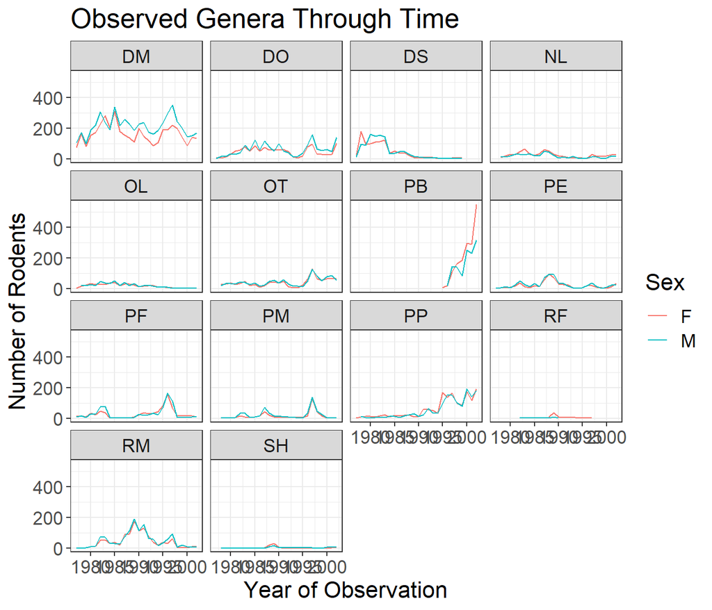

```r
yearly_sex_counts %>%
  ggplot(mapping = aes(x = year, y = n, color = sex)) +
  geom_line() +
  facet_wrap(vars(species_id)) +
  theme_bw() +
  labs(title = "Observed Genera Through Time",
      x = "Year of Observation",
      y = "Number of Rodents",
      color = "Sex") +
  theme(text = element_text(size = 16))
```

```r
    ## sets ALL the text on the plot to be size 16
```

**Note:**  
`theme_bw()` is function for a **specific** theme and `theme()` is a generic function for a **variety** of different themes!

After our manipulations, you may notice that the values on the x-axis are still not properly readable. Let’s swap the orientation of the labels, so the reader doesn’t have to tilt their head when reading our plot! The `coord_flip()` function easily changes the x- and y-axis.

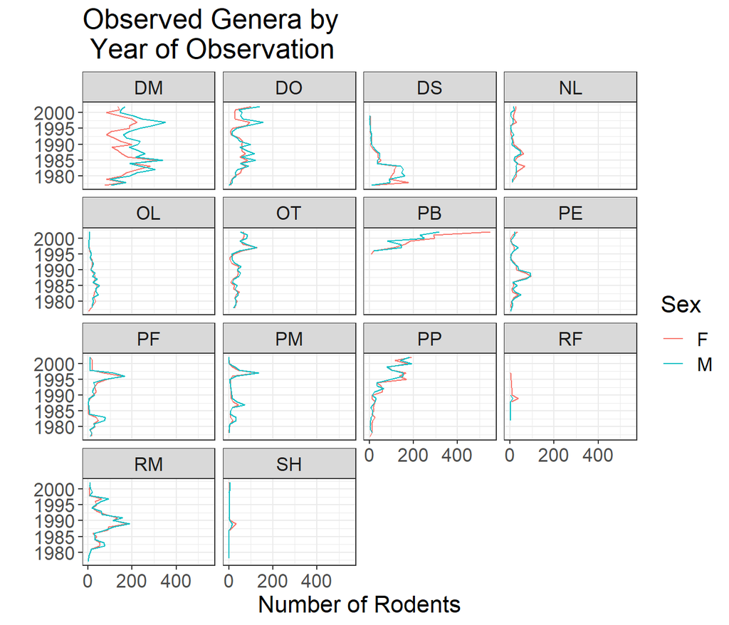

```r
yearly_sex_counts %>%
  ggplot(mapping = aes(x = year, y = n, color = sex)) +
  geom_line() +
  facet_wrap(vars(species_id)) +
  theme_bw() +
  labs(title = "Observed Genera by \n Year of Observation",
      x = "",
      y = "Number of Rodents",
      color = "Sex") +
  theme(text = element_text(size = 16)) +
  coord_flip()
```

This definitely makes the reader tilt their head less! But, the text on the x-axis is a bit too large to separate the numbers. We can specify the text size for each element of the plot independently, if we so wish. This would look something like this:

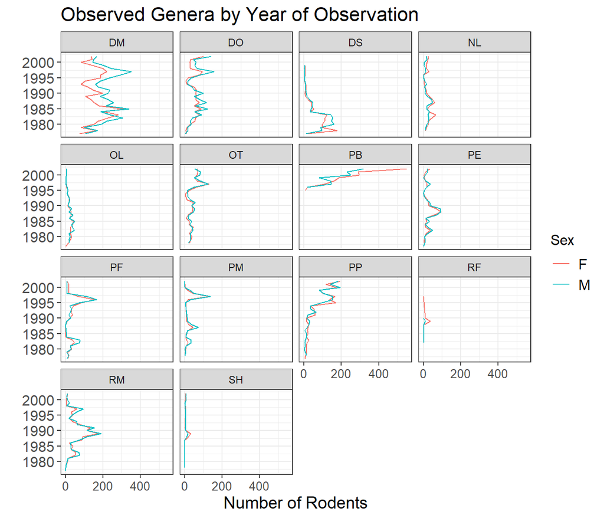

```r
yearly_sex_counts %>%
  ggplot(mapping = aes(x = year, y = n, color = sex)) +
  geom_line() +
  facet_wrap(vars(species_id)) +
  theme_bw() +
  labs(title = "Observed Genera by Year of Observation",
        x = "",
        y = "Number of Rodents",
        color = "Sex") +
  theme(axis.text.x = element_text(size = 10),
        axis.text.y = element_text(size = 12),
        axis.title.x = element_text(size = 14),
        legend.text = element_text(size = 12),
        legend.title = element_text(size = 12),
        plot.title = element_text(size = 16)) +
  coord_flip()
```

## Legend Position

By default in `ggplot2` the legend is positioned on the right hand side. However, you are able to change the position of the legend to the left hand side, the top of the plot, or the bottom of the plot.

This is done by adding a `legend.position` theme to the plot’s `theme()`’s.

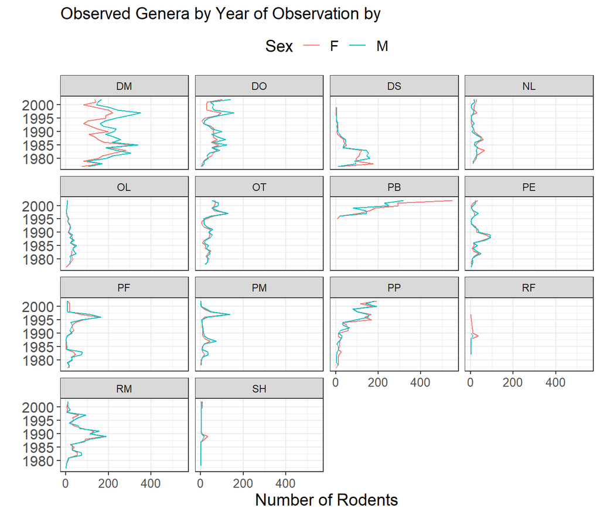

```r
yearly_sex_counts %>%
  ggplot(mapping = aes(x = year, y = n, color = sex)) +
    geom_line() +
    facet_wrap(vars(species_id)) +
    labs(title = "Observed Genera by Year of Observation by",
        x = "",
        y = "Number of Rodents",
        color = "Sex") +
  theme_bw() +
  theme(axis.text.x = element_text(size = 10),
        axis.text.y = element_text(size = 12),
        axis.title.x = element_text(size = 14),
        legend.text = element_text(size = 12),
        legend.title = element_text(size = 14),
        plot.title = element_text(size = 14),
        legend.position = "top") +
  coord_flip()
```

## Removing Grid Lines

By default, the background of a `ggplot()` contains both minor and major gridlines. These can make the plot look a bit busy and difficult for the reader to follow. As you may have guessed, to remove these gridlines, we add another theme to our plot.

This looks like this:

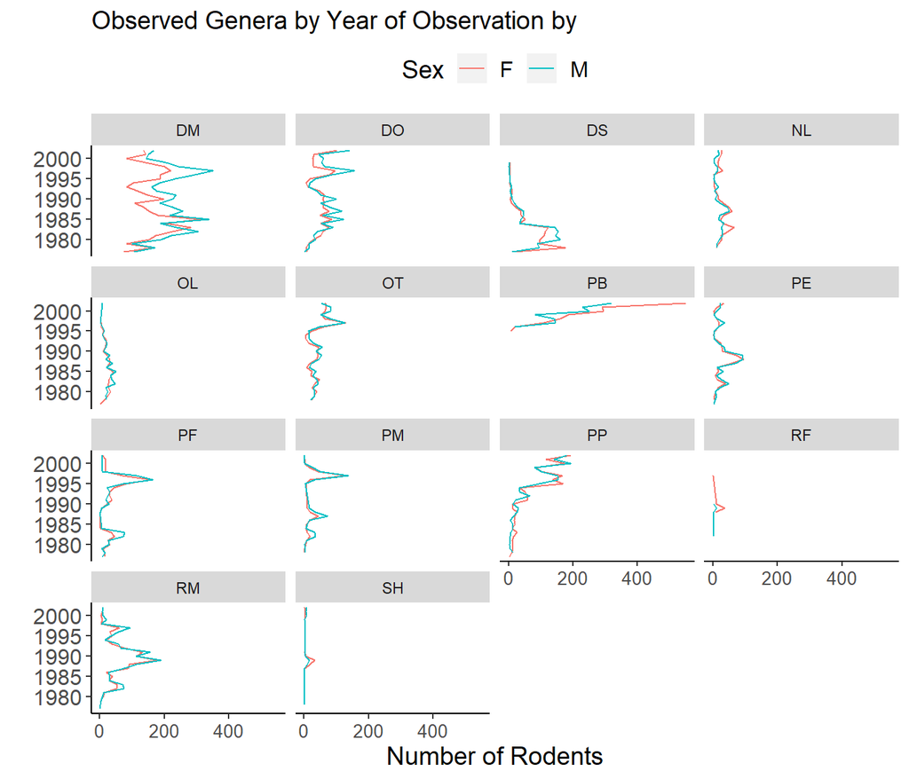

```r
yearly_sex_counts %>%
  ggplot(mapping = aes(x = year, y = n, color = sex)) +
  geom_line() +
  facet_wrap(vars(species_id)) +
  labs(title = "Observed Genera by Year of Observation by",
      x = "",
      y = "Number of Rodents",
      color = "Sex") +
  theme(axis.text.x = element_text(size = 10),
        axis.text.y = element_text(size = 12),
        axis.title.x = element_text(size = 14),
        legend.text = element_text(size = 12),
        legend.title = element_text(size = 14),
        plot.title = element_text(size = 14),
        legend.position = "top",
        ## New themes for the grid lines
        axis.line = element_line(colour = "black"),
        ##
        panel.grid.major = element_blank(),
        panel.grid.minor = element_blank(),
        panel.border = element_blank(),
        panel.background = element_blank()) +
  coord_flip()
```

Let’s break these options down!

- The `axis.line` option declares what color the x- and y-axis lines should be. (Change it to a different color, if you don’t believe me!)
- The `panel.grid.major` removes the major grid (the one associated with the ticks from the x- and y-axis).
- The `panel.grid.minor` removes the minor grid (the one *between* the x- and y-axis ticks).
- The `panel.border` removes the border around the plot.
- The `panel.background` performs a similar action to `theme_bw()`, but it keeps the border around the facet labels.

## Changing Colors

The built in `ggplot()` color scheme may not be what you were looking for, but don’t worry! There are many other color palettes available to use!

You can change the colors used by `ggplot()` a few different ways.

### Manual Specification

Add the `scale_color_manual()` or `scale_fill_manual()` functions to your plot and directly specify the colors you want to use. You can either:

- defining a vector of colors right there (e.g. `values = c("blue", "black", "red", "green")`)
- creating a vector of colors and storing it in an object and calling it (see below)

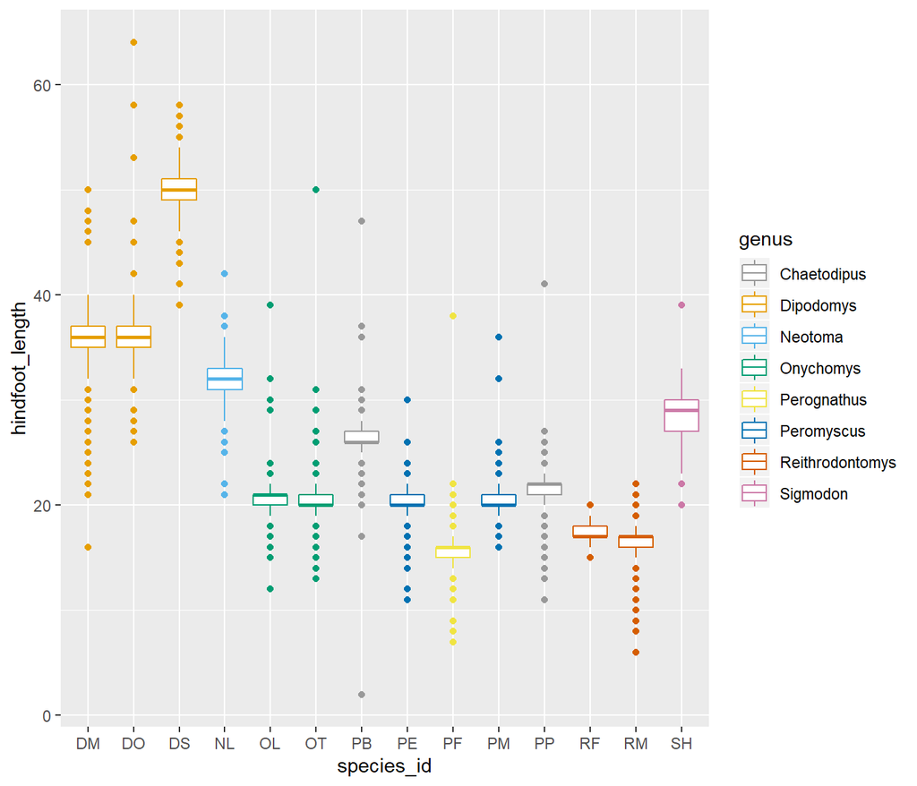

```r
# A color deficient friendly palette with grey:
cbPalette_grey <- c("#999999", "#E69F00", "#56B4E9", "#009E73", "#F0E442", "#0072B2", "#D55E00", "#CC79A7")

# A color deficient friendly palette with black:
cbPalette_blk <- c("#000000", "#E69F00", "#56B4E9", "#009E73", "#F0E442", "#0072B2", "#D55E00", "#CC79A7")

surveys %>%
  ggplot(aes(x = species_id, y = hindfoot_length, color = genus)) +
  geom_boxplot() +
  scale_color_manual(values = cbPalette_grey)
```

### Package Specification

Install a package and use it’s available color scales. Popular options include:

- `RColorBrewer`: using `scale_fill_brewer()` or `scale_colour_brewer()`
- `viridis`: using `scale_colour_viridis_d()` for discrete data, `scale_colour_viridis_c()` for continuous data, with an inside argument of `option = <COLOR>` for your chosen color scheme
- `ggsci`: using `scale_color_<PALNAME>()` or `scale_fill_<PALNAME>()`, where you specify the name of the palette you wish to use (e.g. `scale_color_aaas()`)

### Challenge 9

> With all of this information in hand, please take another five minutes to either improve one of the plots generated in this exercise or create a beautiful graph of your own. Use the RStudio [**`ggplot2`** cheat sheet](https://github.com/rstudio/cheatsheets/raw/master/data-visualization-2.1.pdf) for inspiration. Here are some ideas:
> - See if you can change the thickness of the lines.
> - Try using a different color palette
> - Can you find a way to change the name of the legend? What about its labels? (see http://www.cookbook-r.com/Graphs/Colors_(ggplot2)/).

## Arranging and Exporting Plots

Faceting is a great tool for splitting one plot into multiple plots, but sometimes you may want to produce a single figure that contains multiple plots using different variables or even different data frames. The **`gridExtra`** package allows us to combine separate ggplots into a single figure using `grid.arrange()`:

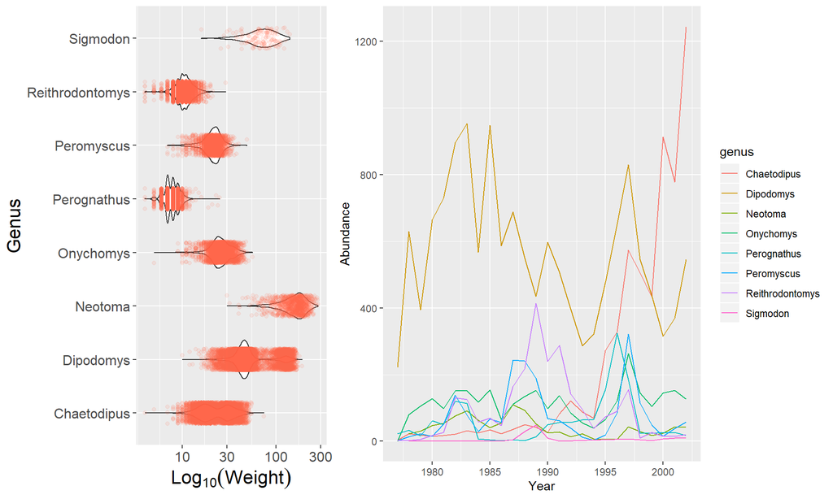

```r
library(gridExtra)

spp_weight_boxplot <- surveys %>%
  ggplot(aes(x = genus, y = weight)) +
  geom_violin() +
  geom_jitter(color = "tomato", width = 0.2, alpha = 0.1) +
  scale_y_log10() +
  ## log (base 10) transforms the y-axis variable
  ## (helps to make the plot less skewed)
  labs(x = "Genus",
       y = expression(Log[10](Weight))) +
  coord_flip() +
  theme(axis.text.y = element_text(size = 12),
        axis.text.x = element_text(size = 12),
        text = element_text(size = 16))

spp_count_plot <- yearly_counts %>%
  ggplot(aes(x = year, y = n, color = genus)) +
  geom_line() +
  labs(x = "Year", y = "Abundance")

grid.arrange(spp_weight_boxplot, spp_count_plot, ncol = 2, widths = c(4, 6))
```

```r
## nrow and ncol specify how many rows/columns you want the arranged plots to be in
## widths specify what proportion of the overall plotting area each plot takes up
```

In addition to the `ncol` and `nrow` arguments, used to make simple arrangements, there are tools for [constructing more complex layouts](https://cran.r-project.org/web/packages/gridExtra/vignettes/arrangeGrob.html).

For more assistance arranging plots with `grid.arrage()`. I find the following vignette **very** helpful!

https://cran.r-project.org/web/packages/egg/vignettes/Ecosystem.html

# Exporting Plots

After creating your plot, you can save it to a file in your favorite format. The Export tab in the **Plot** pane in RStudio will save your plots at low resolution, which will not be accepted by many journals and will not scale well for posters.

Instead, use the `ggsave()` function, which allows you easily change the dimension and resolution of your plot by adjusting the appropriate arguments:

- `width` and `height`: adjust the total plot size in units (“in”, “cm”, or “mm”)
  - If units are not specified, default is inches.
- `dpi`: adjusts the plot resolution. This accepts a string or numeric input:
  - “retina” (320)
  - “print” (300)
  - “screen” (72)

Make sure you have the `fig/` folder in your working directory.

```r
my_plot <- ggplot(data = yearly_sex_counts,
                  mapping = aes(x = year, y = n, color = sex)) +
              geom_line() +
              facet_wrap(vars(species_id)) +
              labs(title = "Observed genera through time",
                    x = "Year of observation",
                    y = "Number of individuals") +
              theme_bw() +
              theme(axis.text.x = element_text(colour = "grey20", size = 12,
                                               angle = 90, hjust = 0.5,
                                               vjust = 0.5),
                    axis.text.y = element_text(colour = "grey20", size = 12),
                    text = element_text(size = 16))

ggsave("fig/yearly_sex_counts.png", my_plot, width = 15, height = 10)

# This also works for grid.arrange() plots
combo_plot <- grid.arrange(spp_weight_boxplot, spp_count_plot,
                           ncol = 2, widths = c(4, 6))

ggsave("fig/combo_plot_abun_weight.png", combo_plot, width = 10, dpi = 300)
```

> Note: The parameters `width` and `height` also determine the font size in the saved plot.

# Tips for Creating Visually Appealing Data Visualizations

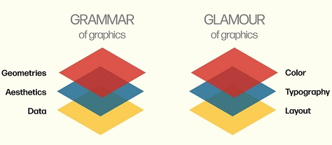

One of my favorite references when I am creating plots are the slides from Will Chase’s presentation at the 2020 RStudio Conference [(link)](https://www.williamrchase.com/slides/assets/player/KeynoteDHTMLPlayer.html#0). Will is a graphic designer and lays out some interesting “best practices” for creating graphics that we can explore. His suggestions are for three components of the plot: layout, typography, and color. Here are some big take-aways that I use when I create a plot!

- Titles should be top-left aligned (usually).

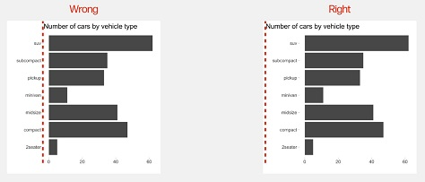

- Don’t make people tilt their head!

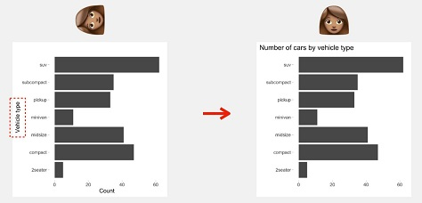

- Don’t use borders!
- Remove grids and lighten as much as possible – don’t use minor grid lines.

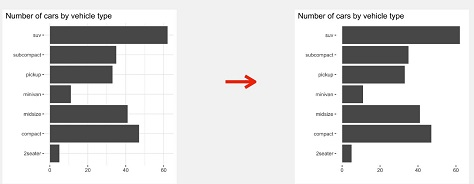

- Legends suck, so find clever ways to eliminate them.

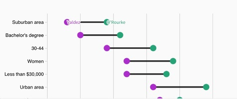

- White space is like garlic; take the amount you think you need and triple it.
- Fonts matter!

[figure not shown]

- Colors are hard, so think about them carefully!

# Instructor Biographies

## Allison Theobold

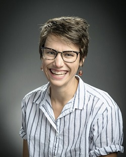

Allison Theobold, originally from Grand Junction, CO, is a sixth-year graduate student studying Statistics Education at Montana State University. Allison graduated from Colorado Mesa University in 2014, earned a Master’s degree in Statistics from Montana State University, and will be defending her dissertation in April of this year. Recognized by both the Department of Mathematical Sciences and the College of Letters and Sciences as an outstanding graduate teacher and researcher, Allison’s passion for teaching data science is infectious. Allison has taught Introduction and Intermediate Statistics to undergraduate and graduate students, while also completing two years of statistical consulting for diverse groups at Montana State. Her experiences as a teacher and consultant established an interest in preparing researchers in the sciences with the computational tools necessary to implement statistics.

## Elijah Meyer

[figure not shown]

Elijah was born and raised in Great Falls, Montana and currently holds a Master’s degree in Statistics from Montana State University. His early research involved sports statistics, focusing in on Fitbit data and Disc Golf visualizations. His recent work includes research on Graduate Teaching Assistants (GTAs) and program development to help better support GTAs when teaching statistics. Many of these projects were presented to audiences at the Joint Statistical Meetings, Cascadia Symposium of Statistics in Sports, and United States Conference on Teaching Statistics 2019. He is currently pursuing a Ph.D. in statistics with a focus on statistics education.

## Sara Mannheimer

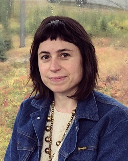

Sara Mannheimer is Assistant Professor and Data Librarian at Montana State University, where she helps shape practices and theories for curation, publication, and preservation of data. Her research is rooted in the examination of the social, ethical, and technical issues that arise as a result of our data-driven world.

# Helper Biographies

## Kelly Loucks

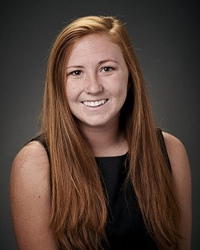

Kelly is from Charlotte, North Carolina and is a second-year Master’s student studying Statistics. She previously earned her Bachelor’s degree in Mathematics with a concentration in Statistics from Appalachian State University. She has worked on research for the United States Forest Service and has taught Introduction to Statistics (216). Her current research is on predicting avalanches on the Seward Highway in Alaska. She enjoys skiing, hiking, ice climbing, and mountain biking in her free time.

## Mark Greenwood

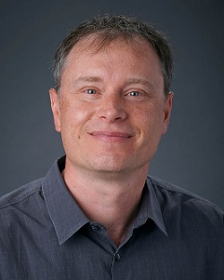

Mark Greenwood has been at Montana State University since 2004 and is a Professor of Statistics in the Department of Mathematical Sciences along with Director of Statistical Consulting and Research Services. His research has spanned a wide variety of areas with applications in environmental and clinical areas being main focus areas and methodological work in clustering and functional data analysis being primary areas of research interest. When not teaching or supervising student research and the work done in SCRS, Mark enjoys hiking, road biking, and fly fishing.

# Workshop Supporters

These workshops are made possible by the generous support of the Montana State University Library and the Statistical Consulting and Research Services.

Workshop build on: 2020-02-19 21:12:27